# 1st class of R

R의 기초 사용법, 기본 연산, 벡터, 행렬, 함수 활용을 실습한다.

### 0. setwd와 getwd

setwd() 함수는 working directory를 변경하는 함수로, 파일을 읽거나 저장할 때 기본 경로를 지정하는데 사용된다.  
getwd() 함수는 현재 작업 디렉토리를 확인하는 함수로, 이 코드를 실행하면 현재 작업 디렉토리 경로가 출력된다.

```r
setwd("/bce/lectures/2024-biomedical-science-programming/202255669/9")
getwd()
```

```
[1] "/bce/lectures/2024-biomedical-science-programming/202255669/9"
```

### 1. Boolean과 결측치

```r
TRUE
```

```
[1] TRUE
```

```r
FALSE
```

```
[1] FALSE
```

```r
NA # 결측값
```

```
[1] NA
```

### 2. 벡터 (c)

0부터 9까지의 숫자로 구성된 벡터 a를 출력한다.

```r
a <- c(0,1,2,3,4,5,6,7,8,9)
a
```

```
 [1] 0 1 2 3 4 5 6 7 8 9
```

### 3. 행렬

5x2 행렬로 변환해 출력한다.

```r
m <- matrix(a, nrow=5, ncol=2)
m
```

```
     [,1] [,2]
[1,]    0    5
[2,]    1    6
[3,]    2    7
[4,]    3    8
[5,]    4    9
```

attributes: m의 속성을 확인할 수 있다.

```r
attributes(m)
```

```
$dim
[1] 5 2
```

### 4. 벡터 활용

벡터의 n번째 element를 추출한다.

```r
a[10]
```

```
[1] 9
```

```r
a[c(2,5)]
```

```
[1] 1 4
```

벡터를 결합할 수 있다.

```r
i <- a[c(2,5)]
j <- a[c(9,3)]
c(i, j)
```

```
[1] 1 4 8 2
```

특정 element를 제거한다.

```r
a[-3]
```

```
[1] 0 1 3 4 5 6 7 8 9
```

```r
a[c(-3, -7)]
```

```
[1] 0 1 3 4 5 7 8 9
```

### 5. 기본 연산자

단순 덧셈을 수행한다.

```r
1 + 1
```

```
[1] 2
```

각 element에 대한 덧셈과 곱셈을 수행한다.

```r
a + 1
```

```
 [1]  1  2  3  4  5  6  7  8  9 10
```

```r
a * 3
```

```
 [1]  0  3  6  9 12 15 18 21 24 27
```

나눗셈과 거듭제곱 연산을 수행한다.

```r
1 / 3
```

```
[1] 0.3333333
```

```r
a / 2
```

```
 [1] 0.0 0.5 1.0 1.5 2.0 2.5 3.0 3.5 4.0 4.5
```

```r
a^1.2
```

```
 [1]  0.000000  1.000000  2.297397  3.737193  5.278032  6.898648  8.585814 10.330412 12.125733 13.966610
```

나머지 연산을 수행한다.

```r
a %% 2
```

```
 [1] 0 1 0 1 0 1 0 1 0 1
```

정수 나눗셈을 수행한다.

```r
a %/% 2
```

```
 [1] 0 0 1 1 2 2 3 3 4 4
```

### 6. 할당 연산자

b와 k에 a를 할당한다.

```r
b <- a
a -> k
b
```

```
 [1] 0 1 2 3 4 5 6 7 8 9
```

```r
k
```

```
 [1] 0 1 2 3 4 5 6 7 8 9
```

### 7. 비교 연산자

비교연산자는 Numpy처럼 동작한다.

```r
a == 3
```

```
 [1] FALSE FALSE FALSE  TRUE FALSE FALSE FALSE FALSE FALSE FALSE
```

```r
a > 3
```

```
 [1] FALSE FALSE FALSE FALSE  TRUE  TRUE  TRUE  TRUE  TRUE  TRUE
```

```r
a <= 3
```

```
 [1]  TRUE  TRUE  TRUE  TRUE FALSE FALSE FALSE FALSE FALSE FALSE
```

```r
a != 2
```

```
 [1]  TRUE  TRUE FALSE  TRUE  TRUE  TRUE  TRUE  TRUE  TRUE  TRUE
```

a에서 3보다 작은 요소만 선택한다.

```r
a[a < 3]
```

```
[1] 0 1 2
```

### 8. 논리 연산자

AND 연산을 수행한다.

```r
a & 3
```

```
 [1] FALSE  TRUE  TRUE  TRUE  TRUE  TRUE  TRUE  TRUE  TRUE  TRUE
```

“명제”에 대한 AND연산을 수행한다다

```r
10 > 3 && 6 > 1
```

```
[1] TRUE
```

OR 연산을 수행한다.

```r
a | 3
```

```
 [1] TRUE TRUE TRUE TRUE TRUE TRUE TRUE TRUE TRUE TRUE
```

### 9. 논리 벡터 비교

```r
i <- a > 3
j <- a > 5

i == j
```

```
 [1]  TRUE  TRUE  TRUE  TRUE FALSE FALSE  TRUE  TRUE  TRUE  TRUE
```

```r
i & j
```

```
 [1] FALSE FALSE FALSE FALSE FALSE FALSE  TRUE  TRUE  TRUE  TRUE
```

### 10. 숫자 순열 생성

```r
1:10
```

```
 [1]  1  2  3  4  5  6  7  8  9 10
```

### 11. 원소가 벡터 내에 있는지 확인하는 %in%

```r
1 %in% a
```

```
[1] TRUE
```

### 12. 행렬 곱연산 %*%

전치 행렬 반환: 행과 열을 바꾼다.

```r
t(m)
```

```
     [,1] [,2] [,3] [,4] [,5]
[1,]    0    1    2    3    4
[2,]    5    6    7    8    9
```

행렬 곱셈을 수행한다.

```r
m %*% t(m)
```

```
     [,1] [,2] [,3] [,4] [,5]
[1,]   25   30   35   40   45
[2,]   30   37   44   51   58
[3,]   35   44   53   62   71
[4,]   40   51   62   73   84
[5,]   45   58   71   84   97
```

### 13. help, example, demo

help: 해당 명령어 사용법에 대한 설명을 확인할 수 있다.

```r
help(solve)
```

example: 해당 함수의 사용 예제를 보여준다.

```r
example(solve)
```

```
solve> hilbert <- function(n) { i <- 1:n; 1 / outer(i - 1, i, `+`) }

solve> h8 <- hilbert(8); h8
          [,1]      [,2]      [,3]       [,4]       [,5]       [,6]       [,7]       [,8]
[1,] 1.0000000 0.5000000 0.3333333 0.25000000 0.20000000 0.16666667 0.14285714 0.12500000
[2,] 0.5000000 0.3333333 0.2500000 0.20000000 0.16666667 0.14285714 0.12500000 0.11111111
[3,] 0.3333333 0.2500000 0.2000000 0.16666667 0.14285714 0.12500000 0.11111111 0.10000000
[4,] 0.2500000 0.2000000 0.1666667 0.14285714 0.12500000 0.11111111 0.10000000 0.09090909
[5,] 0.2000000 0.1666667 0.1428571 0.12500000 0.11111111 0.10000000 0.09090909 0.08333333
[6,] 0.1666667 0.1428571 0.1250000 0.11111111 0.10000000 0.09090909 0.08333333 0.07692308
[7,] 0.1428571 0.1250000 0.1111111 0.10000000 0.09090909 0.08333333 0.07692308 0.07142857
[8,] 0.1250000 0.1111111 0.1000000 0.09090909 0.08333333 0.07692308 0.07142857 0.06666667

solve> sh8 <- solve(h8)

solve> round(sh8 %*% h8, 3)
     [,1] [,2] [,3] [,4] [,5] [,6] [,7] [,8]
[1,]    1    0    0    0    0    0    0    0
[2,]    0    1    0    0    0    0    0    0
[3,]    0    0    1    0    0    0    0    0
[4,]    0    0    0    1    0    0    0    0
[5,]    0    0    0    0    1    0    0    0
[6,]    0    0    0    0    0    1    0    0
[7,]    0    0    0    0    0    0    1    0
[8,]    0    0    0    0    0    0    0    1

solve> A <- hilbert(4)

solve> A[] <- as.complex(A)

solve> ## might not be supported on all platforms
solve> try(solve(A))
        [,1]     [,2]     [,3]     [,4]
[1,]   16+0i  -120+0i   240+0i  -140+0i
[2,] -120+0i  1200+0i -2700+0i  1680+0i
[3,]  240+0i -2700+0i  6480+0i -4200+0i
[4,] -140+0i  1680+0i -4200+0i  2800+0i
```

demo: 해당 함수 사용 예제와 기능을 시각적으로 학습하는 데 도움을 준다.

```
    demo(graphics)
    ---- ~~~~~~~~

> #  Copyright (C) 1997-2009 The R Core Team
>
> require(datasets)

> require(grDevices); require(graphics)

> ## Here is some code which illustrates some of the differences between
> ## R and S graphics capabilities.  Note that colors are generally specified
> ## by a character string name (taken from the X11 rgb.txt file) and that line
> ## textures are given similarly.  The parameter "bg" sets the background
> ## parameter for the plot and there is also an "fg" parameter which sets
> ## the foreground color.
>
>
> x <- stats::rnorm(50)

> opar <- par(bg = "white")

> plot(x, ann = FALSE, type = "n")

> abline(h = 0, col = gray(.90))

> lines(x, col = "green4", lty = "dotted")

> points(x, bg = "limegreen", pch = 21)

> title(main = "Simple Use of Color In a Plot",
+       xlab = "Just a Whisper of a Label",
+       col.main = "blue", col.lab = gray(.8),
+       cex.main = 1.2, cex.lab = 1.0, font.main = 4, font.lab = 3)

> ## A little color wheel.   This code just plots equally spaced hues in
> ## a pie chart.   If you have a cheap SVGA monitor (like me) you will
> ## probably find that numerically equispaced does not mean visually
> ## equispaced.  On my display at home, these colors tend to cluster at
> ## the RGB primaries.  On the other hand on the SGI Indy at work the
> ## effect is near perfect.
>
> par(bg = "gray")

> pie(rep(1,24), col = rainbow(24), radius = 0.9)
```

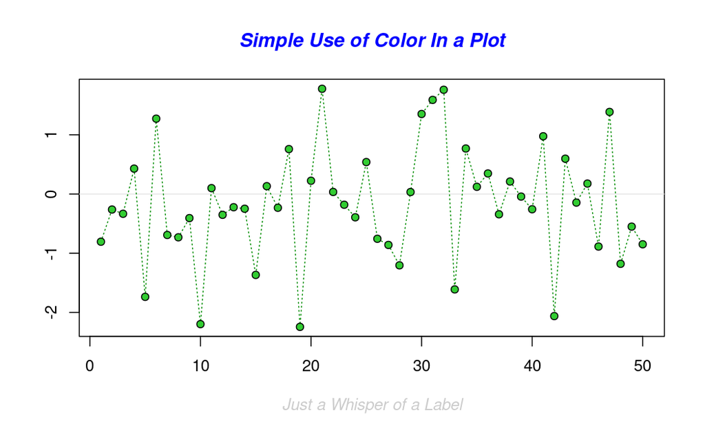

```
> title(main = "A Sample Color Wheel", cex.main = 1.4, font.main = 3)

> title(xlab = "(Use this as a test of monitor linearity)",
+       cex.lab = 0.8, font.lab = 3)

> ## We have already confessed to having these.  This is just showing off X11
> ## color names (and the example (from the postscript manual) is pretty "cute".
>
> pie.sales <- c(0.12, 0.3, 0.26, 0.16, 0.04, 0.12)

> names(pie.sales) <- c("Blueberry", "Cherry",
+             "Apple", "Boston Cream", "Other", "Vanilla Cream")

> pie(pie.sales,
+     col = c("purple","violetred1","green3","cornsilk","cyan","white"))
```

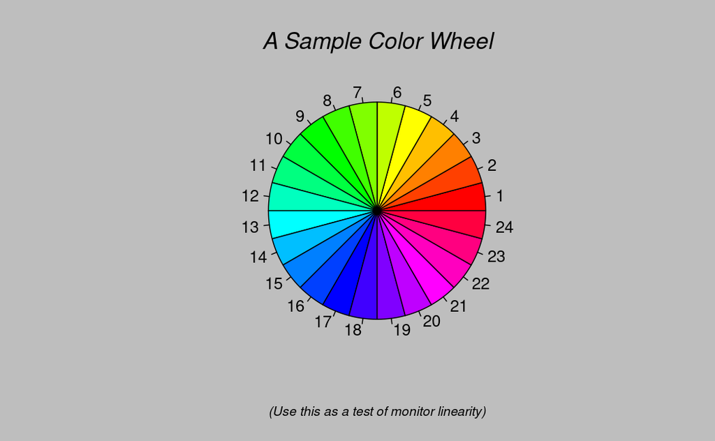

```
> title(main = "January Pie Sales", cex.main = 1.8, font.main = 1)

> title(xlab = "(Don't try this at home kids)", cex.lab = 0.8, font.lab = 3)

> ## Boxplots:  I couldn't resist the capability for filling the "box".
> ## The use of color seems like a useful addition, it focuses attention
> ## on the central bulk of the data.
>
> par(bg="cornsilk")

> n <- 10

> g <- gl(n, 100, n*100)

> x <- rnorm(n*100) + sqrt(as.numeric(g))

> boxplot(split(x,g), col="lavender", notch=TRUE)
```

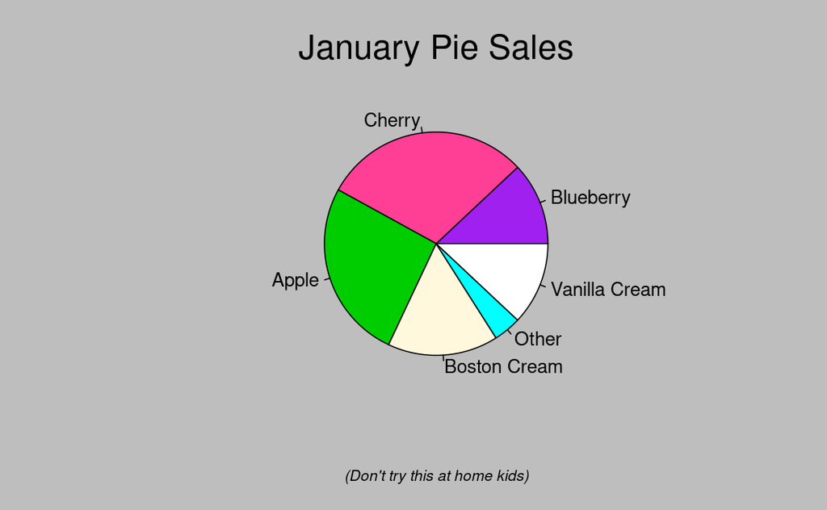

```
> title(main="Notched Boxplots", xlab="Group", font.main=4, font.lab=1)

> ## An example showing how to fill between curves.
>
> par(bg="white")

> n <- 100

> x <- c(0,cumsum(rnorm(n)))

> y <- c(0,cumsum(rnorm(n)))

> xx <- c(0:n, n:0)

> yy <- c(x, rev(y))

> plot(xx, yy, type="n", xlab="Time", ylab="Distance")
```

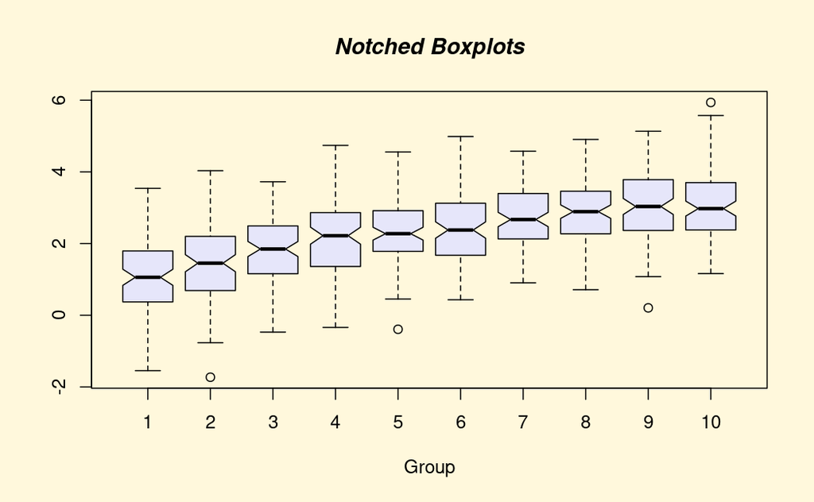

```
> polygon(xx, yy, col="gray")

> title("Distance Between Brownian Motions")

> ## Colored plot margins, axis labels and titles.   You do need to be
> ## careful with these kinds of effects.   It's easy to go completely
> ## over the top and you can end up with your lunch all over the keyboard.
> ## On the other hand, my market research clients love it.
>
> x <- c(0.00, 0.40, 0.86, 0.85, 0.69, 0.48, 0.54, 1.09, 1.11, 1.73, 2.05, 2.02)

> par(bg="lightgray")

> plot(x, type="n", axes=FALSE, ann=FALSE)
```

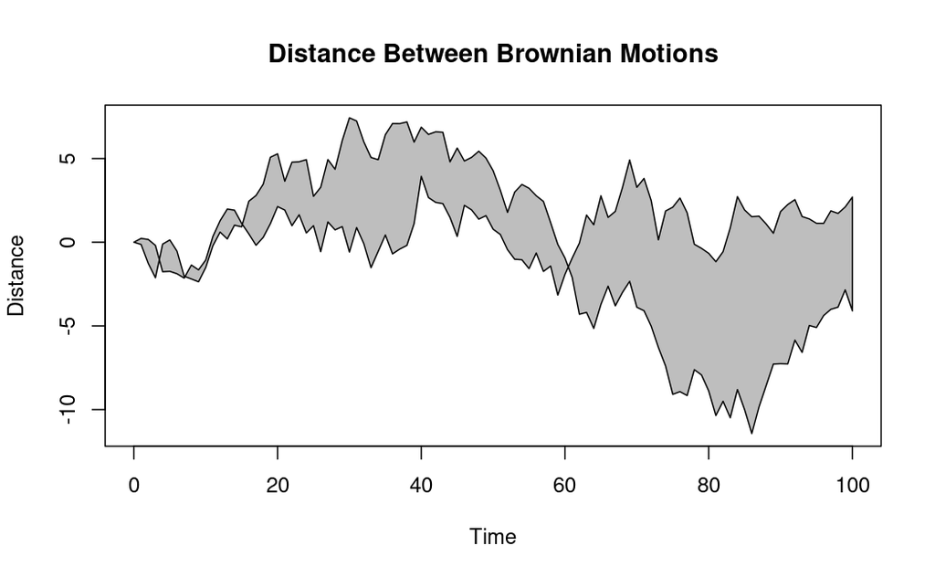

```
> usr <- par("usr")

> rect(usr[1], usr[3], usr[2], usr[4], col="cornsilk", border="black")

> lines(x, col="blue")

> points(x, pch=21, bg="lightcyan", cex=1.25)

> axis(2, col.axis="blue", las=1)

> axis(1, at=1:12, lab=month.abb, col.axis="blue")

> box()

> title(main= "The Level of Interest in R", font.main=4, col.main="red")

> title(xlab= "1996", col.lab="red")

> ## A filled histogram, showing how to change the font used for the
> ## main title without changing the other annotation.
>
> par(bg="cornsilk")

> x <- rnorm(1000)

> hist(x, xlim=range(-4, 4, x), col="lavender", main="")
```

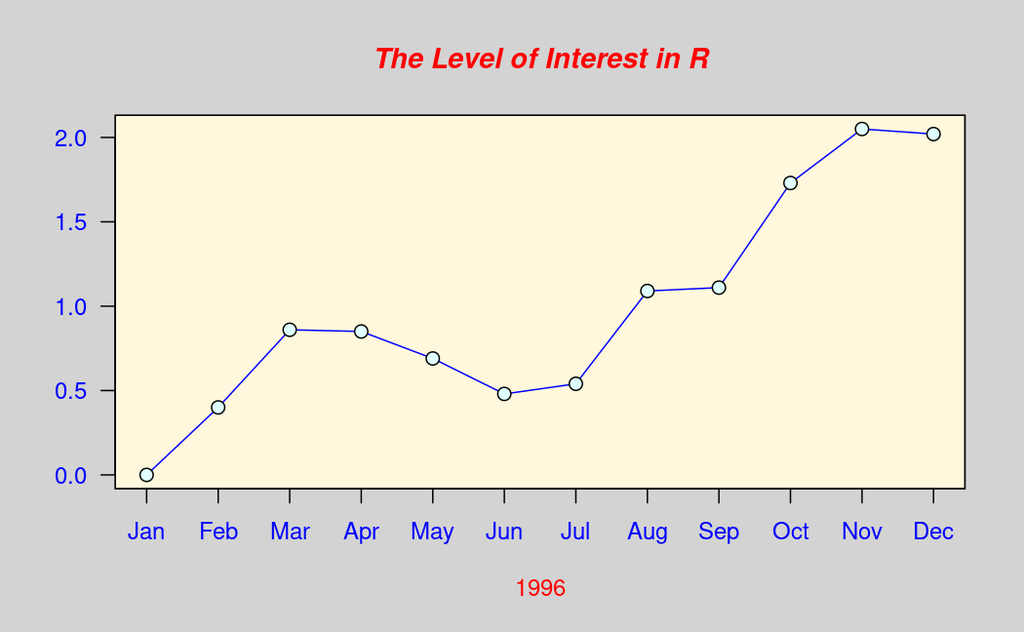

```
> title(main="1000 Normal Random Variates", font.main=3)

> ## A scatterplot matrix
> ## The good old Iris data (yet again)
>
> pairs(iris[1:4], main="Edgar Anderson's Iris Data", font.main=4, pch=19)
```

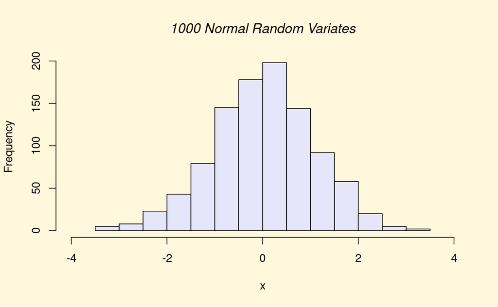

```
> pairs(iris[1:4], main="Edgar Anderson's Iris Data", pch=21,
+       bg = c("red", "green3", "blue")[unclass(iris$Species)])
```

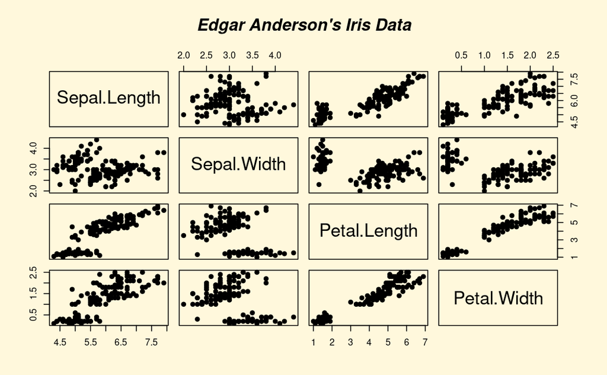

```
> ## Contour plotting
> ## This produces a topographic map of one of Auckland's many volcanic "peaks".
>
> x <- 10*1:nrow(volcano)

> y <- 10*1:ncol(volcano)

> lev <- pretty(range(volcano), 10)

> par(bg = "lightcyan")

> pin <- par("pin")

> xdelta <- diff(range(x))

> ydelta <- diff(range(y))

> xscale <- pin[1]/xdelta

> yscale <- pin[2]/ydelta

> scale <- min(xscale, yscale)

> xadd <- 0.5*(pin[1]/scale - xdelta)

> yadd <- 0.5*(pin[2]/scale - ydelta)

> plot(numeric(0), numeric(0),
+      xlim = range(x)+c(-1,1)*xadd, ylim = range(y)+c(-1,1)*yadd,
+      type = "n", ann = FALSE)
```

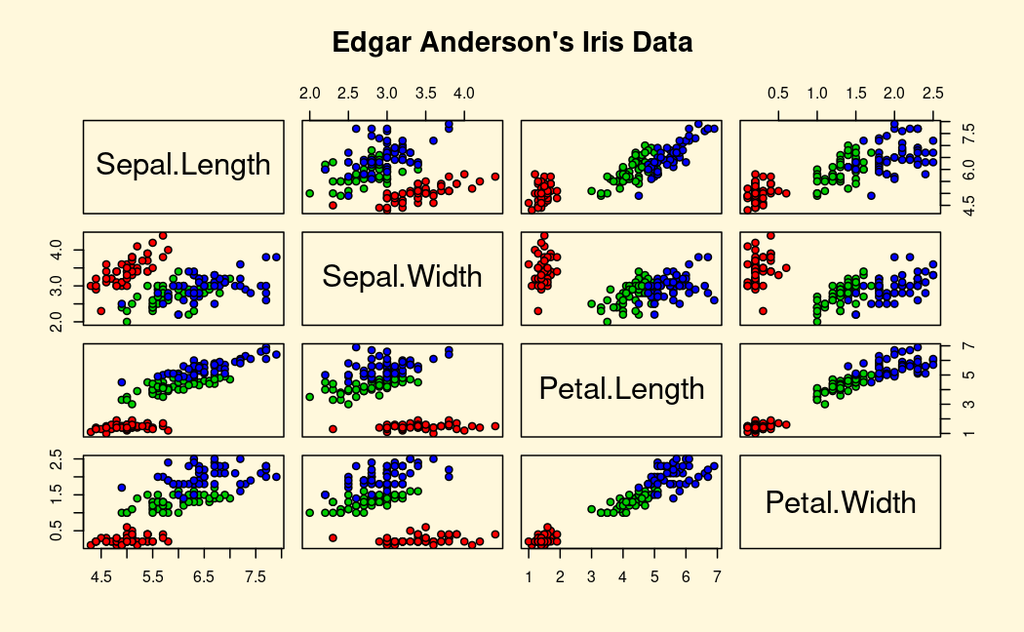

```
> usr <- par("usr")

> rect(usr[1], usr[3], usr[2], usr[4], col="green3")

> contour(x, y, volcano, levels = lev, col="yellow", lty="solid", add=TRUE)

> box()

> title("A Topographic Map of Maunga Whau", font= 4)

> title(xlab = "Meters North", ylab = "Meters West", font= 3)

> mtext("10 Meter Contour Spacing", side=3, line=0.35, outer=FALSE,
+       at = mean(par("usr")[1:2]), cex=0.7, font=3)

> ## Conditioning plots
>
> par(bg="cornsilk")

> coplot(lat ~ long | depth, data = quakes, pch = 21, bg = "green3")
```

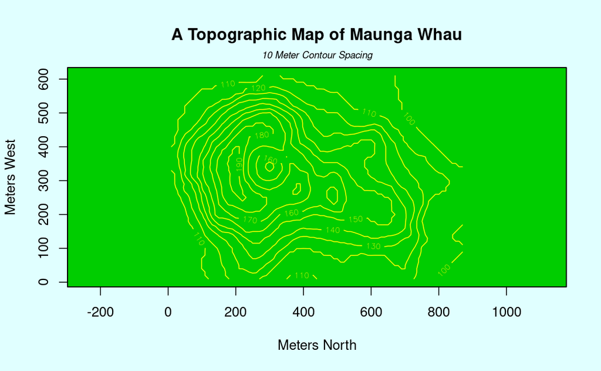

```
> par(opar)
```

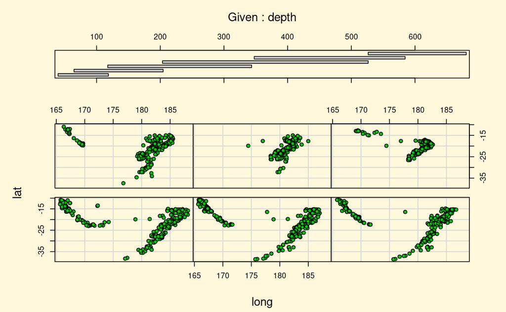

```r
demo(graphics)
```

### 14. data

R에 내장된 데이터를 확인한다. 해당 데이터셋을 불러올 때 사용한다.

```r
data(mtcars)
mtcars
```

|  | mpg | cyl | disp | hp | drat | wt | qsec | vs | am | gear | carb |
| --- | --- | --- | --- | --- | --- | --- | --- | --- | --- | --- | --- |
| Mazda RX4 | 21.0 | 6 | 160.0 | 110 | 3.90 | 2.620 | 16.46 | 0 | 1 | 4 | 4 |
| Mazda RX4 Wag | 21.0 | 6 | 160.0 | 110 | 3.90 | 2.875 | 17.02 | 0 | 1 | 4 | 4 |
| Datsun 710 | 22.8 | 4 | 108.0 | 93 | 3.85 | 2.320 | 18.61 | 1 | 1 | 4 | 1 |
| Hornet 4 Drive | 21.4 | 6 | 258.0 | 110 | 3.08 | 3.215 | 19.44 | 1 | 0 | 3 | 1 |
| Hornet Sportabout | 18.7 | 8 | 360.0 | 175 | 3.15 | 3.440 | 17.02 | 0 | 0 | 3 | 2 |
| Valiant | 18.1 | 6 | 225.0 | 105 | 2.76 | 3.460 | 20.22 | 1 | 0 | 3 | 1 |
| Duster 360 | 14.3 | 8 | 360.0 | 245 | 3.21 | 3.570 | 15.84 | 0 | 0 | 3 | 4 |
| Merc 240D | 24.4 | 4 | 146.7 | 62 | 3.69 | 3.190 | 20.00 | 1 | 0 | 4 | 2 |
| Merc 230 | 22.8 | 4 | 140.8 | 95 | 3.92 | 3.150 | 22.90 | 1 | 0 | 4 | 2 |
| Merc 280 | 19.2 | 6 | 167.6 | 123 | 3.92 | 3.440 | 18.30 | 1 | 0 | 4 | 4 |

[output cut: 22 more lines]